# Assignment 3_editedLastcopy

## Assignment 3

**TU Delft and WUR**  
**Q1 2024**  
**Instructor:** Theodoros Chatzivasileiadis  
**Instructor:** Hans Hoogenboom  
**TA:** Ka Yi Chua  
**[Metropolitan Data 1](https://jhoogenboom.github.io/spatial-data-science/_index.html)**

**This homework assignment document will guide you through five tasks in cleaning your data.**

1. Reading and Summarizing the Data.
2. Subsetting the Data.
3. Manage Missing Data.
4. Shape the Data.
5. Saving the Results.

# NB: From now on you should submit 1) your notebook with the answers, remember that comments are good practice, 2) a working Git page with your assignment

## Exercise 1: Loading the data:

- Load the `goodreads.csv` file into Python
- Explore it by looking at first and last 5 rows
- Change the column names to `["rating", 'review_count', 'isbn', 'booktype','author_url', 'year', 'genre_urls', 'dir','rating_count', 'name']`

```python
# This imports the pandas library
import pandas as pd
# use pd.read_csv() to read the CSV file located at "data/goodreads.csv"
# The header=None parameter indicates that the CSV file does not have a header row, so pandas will not use the first row as column names
# Instead, it will assign default integer column names. These we can easily change later
gr = pd.read_csv('data/goodreads.csv', header=None)
# rename columns names
gr.columns = ["rating", 'review_count', 'isbn', 'booktype', 'author_url', 'year', 'genre_urls', 'dir', 'rating_count', 'name']
#display new column names and first and last 5 rows
gr.head()
```

|  | rating | review_count | isbn | booktype | author_url | year | genre_urls | dir | rating_count | name |
| --- | --- | --- | --- | --- | --- | --- | --- | --- | --- | --- |
| 0 | 4.40 | 136455.0 | 0439023483 | good_reads:book | https://www.goodreads.com/author/show/153394.S... | 2008.0 | /genres/young-adult\|/genres/science-fiction\|/g... | dir01/2767052-the-hunger-games.html | 2958974.0 | The Hunger Games (The Hunger Games, #1) |
| 1 | 4.41 | 16648.0 | 0439358078 | good_reads:book | https://www.goodreads.com/author/show/1077326.... | 2003.0 | /genres/fantasy\|/genres/young-adult\|/genres/fi... | dir01/2.Harry_Potter_and_the_Order_of_the_Phoe... | 1284478.0 | Harry Potter and the Order of the Phoenix (Har... |
| 2 | 3.56 | 85746.0 | 0316015849 | good_reads:book | https://www.goodreads.com/author/show/941441.S... | 2005.0 | /genres/young-adult\|/genres/fantasy\|/genres/ro... | dir01/41865.Twilight.html | 2579564.0 | Twilight (Twilight, #1) |
| 3 | 4.23 | 47906.0 | 0061120081 | good_reads:book | https://www.goodreads.com/author/show/1825.Har... | 1960.0 | /genres/classics\|/genres/fiction\|/genres/histo... | dir01/2657.To_Kill_a_Mockingbird.html | 2078123.0 | To Kill a Mockingbird |
| 4 | 4.23 | 34772.0 | 0679783261 | good_reads:book | https://www.goodreads.com/author/show/1265.Jan... | 1813.0 | /genres/classics\|/genres/fiction\|/genres/roman... | dir01/1885.Pride_and_Prejudice.html | 1388992.0 | Pride and Prejudice |

```python
gr.tail()
```

|  | rating | review_count | isbn | booktype | author_url | year | genre_urls | dir | rating_count | name |
| --- | --- | --- | --- | --- | --- | --- | --- | --- | --- | --- |
| 5995 | 4.17 | 2226.0 | 0767913736 | good_reads:book | https://www.goodreads.com/author/show/44565.Ca... | 2005.0 | /genres/history\|/genres/non-fiction\|/genres/bi... | dir60/78508.The_River_of_Doubt.html | 16618.0 | The River of Doubt |
| 5996 | 3.99 | 775.0 | 1416909427 | good_reads:book | https://www.goodreads.com/author/show/151371.J... | 2006.0 | /genres/young-adult\|/genres/realistic-fiction\|... | dir60/259068.Shug.html | 6179.0 | Shug |
| 5997 | 3.78 | 540.0 | 1620612321 | good_reads:book | https://www.goodreads.com/author/show/5761314.... | 2012.0 | /genres/contemporary\|/genres/romance\|/genres/y... | dir60/13503247-flawed.html | 2971.0 | Flawed |
| 5998 | 3.91 | 281.0 | NaN | good_reads:book | https://www.goodreads.com/author/show/1201952.... | 2006.0 | /genres/religion\|/genres/islam\|/genres/religio... | dir60/2750008.html | 3083.0 | Ø£Ø³Ø¹Ø¯ Ø§Ù Ø±Ø£Ø© ÙÙ Ø§ÙØ¹Ø§ÙÙ |
| 5999 | 4.35 | 61.0 | 0786929081 | good_reads:book | https://www.goodreads.com/author/show/1023510.... | 2001.0 | /genres/fiction\|/genres/fantasy\|/genres/magic\|... | dir60/66677.Legacy_of_the_Drow_Collector_s_Edi... | 3982.0 | Legacy of the Drow Collector's Edition (Legacy... |

## Exercise 2: Subsetting the data

- Subset the data by creating new dataframe only with `["rating", 'isbn', 'author_url', 'year', 'genre_urls', 'name']`

```python
# we create a new DataFrame gr_subset from an existing DataFrame gr.
# The list ["rating", 'isbn', 'author_url', 'year', 'genre_urls', 'name'] specifies the column names we want to extract from the original DataFrame gr
gr_subset = gr[["rating", 'isbn', 'author_url', 'year', 'genre_urls', 'name']]

# Just a quick look on the newly created dataframe
display(gr_subset)
```

|  | rating | isbn | author_url | year | genre_urls | name |
| --- | --- | --- | --- | --- | --- | --- |
| 0 | 4.40 | 0439023483 | https://www.goodreads.com/author/show/153394.S... | 2008.0 | /genres/young-adult\|/genres/science-fiction\|/g... | The Hunger Games (The Hunger Games, #1) |
| 1 | 4.41 | 0439358078 | https://www.goodreads.com/author/show/1077326.... | 2003.0 | /genres/fantasy\|/genres/young-adult\|/genres/fi... | Harry Potter and the Order of the Phoenix (Har... |
| 2 | 3.56 | 0316015849 | https://www.goodreads.com/author/show/941441.S... | 2005.0 | /genres/young-adult\|/genres/fantasy\|/genres/ro... | Twilight (Twilight, #1) |
| 3 | 4.23 | 0061120081 | https://www.goodreads.com/author/show/1825.Har... | 1960.0 | /genres/classics\|/genres/fiction\|/genres/histo... | To Kill a Mockingbird |
| 4 | 4.23 | 0679783261 | https://www.goodreads.com/author/show/1265.Jan... | 1813.0 | /genres/classics\|/genres/fiction\|/genres/roman... | Pride and Prejudice |
| ... | ... | ... | ... | ... | ... | ... |
| 5995 | 4.17 | 0767913736 | https://www.goodreads.com/author/show/44565.Ca... | 2005.0 | /genres/history\|/genres/non-fiction\|/genres/bi... | The River of Doubt |
| 5996 | 3.99 | 1416909427 | https://www.goodreads.com/author/show/151371.J... | 2006.0 | /genres/young-adult\|/genres/realistic-fiction\|... | Shug |
| 5997 | 3.78 | 1620612321 | https://www.goodreads.com/author/show/5761314.... | 2012.0 | /genres/contemporary\|/genres/romance\|/genres/y... | Flawed |
| 5998 | 3.91 | NaN | https://www.goodreads.com/author/show/1201952.... | 2006.0 | /genres/religion\|/genres/islam\|/genres/religio... | Ø£Ø³Ø¹Ø¯ Ø§Ù Ø±Ø£Ø© ÙÙ Ø§ÙØ¹Ø§ÙÙ |
| 5999 | 4.35 | 0786929081 | https://www.goodreads.com/author/show/1023510.... | 2001.0 | /genres/fiction\|/genres/fantasy\|/genres/magic\|... | Legacy of the Drow Collector's Edition (Legacy... |

6000 rows × 6 columns

## Exercise 3: Manage Missing Data

We’ve got a number of ways in general of dealing with missing data. These involve

1. Dropping off cases (or rows) in the data with any missing variables
2. Excluding variables in the data with any missing data
3. Selectively choosing indicators with only a limited amount of missing data
4. Replacing missing variables with averages, or other representative values
5. Creating a separate model to predict missing data
- Count the missing values in each column
- Manage the missing values (delete or replace values or leave them as they are) and briefly explain your choice for each column

```python
# In order to count how many missing values (NaN) are present in each column.
# We check each element in the DataFrame gr_subset to see if it contains a null (or NaN) value using the function .isnull()
# .isnull() returns a DataFrame of the same shape as gr_subset, with True for null values and False for non-null values.
# .sum(): sums the True values (which are treated as 1) column-wise, giving the total count of missing values in each column of the DataFrame.
print("Missing per column:\n", gr_subset.isnull().sum())
```

```
Missing per column:
 rating          2
isbn          477
author_url      2
year            7
genre_urls     62
name            2
dtype: int64
```

```python
# A quick check of the NaN values in the 'name' column reveals that the 'rating', 'name' and 'author_url' columns share the same rows with missing values (NaN).
gr_subset.loc[gr_subset.name.isnull()]
```

|  | rating | isbn | author_url | year | genre_urls | name |
| --- | --- | --- | --- | --- | --- | --- |
| 3643 | NaN | NaN | NaN | NaN | NaN | NaN |
| 5282 | NaN | NaN | NaN | NaN | NaN | NaN |

```python
# These 2 rows will be deleted from our new dataframe because we don't need them to our dataframe.
# By dropping these rows we handled the NaN values for those 3 columns 'rating', 'name' and 'author_url'
gr_subset = gr_subset.dropna(subset=['rating'], inplace=False)

# Confirmation of deletion
gr_subset.loc[gr_subset.name.isnull()]
```

|  | rating | isbn | author_url | year | genre_urls | name |
| --- | --- | --- | --- | --- | --- | --- |

```python
#We decided to keep the rest NaN values and replace them with "unknown" beacuse the other columns give us important
# information and one misssing value in a column does not mean that the whole row is not essential.
gr_subset= gr_subset.fillna("unknown")

# Display the new dataframe to see changes
display(gr_subset)
```

|  | rating | isbn | author_url | year | genre_urls | name |
| --- | --- | --- | --- | --- | --- | --- |
| 0 | 4.40 | 0439023483 | https://www.goodreads.com/author/show/153394.S... | 2008.0 | /genres/young-adult\|/genres/science-fiction\|/g... | The Hunger Games (The Hunger Games, #1) |
| 1 | 4.41 | 0439358078 | https://www.goodreads.com/author/show/1077326.... | 2003.0 | /genres/fantasy\|/genres/young-adult\|/genres/fi... | Harry Potter and the Order of the Phoenix (Har... |
| 2 | 3.56 | 0316015849 | https://www.goodreads.com/author/show/941441.S... | 2005.0 | /genres/young-adult\|/genres/fantasy\|/genres/ro... | Twilight (Twilight, #1) |
| 3 | 4.23 | 0061120081 | https://www.goodreads.com/author/show/1825.Har... | 1960.0 | /genres/classics\|/genres/fiction\|/genres/histo... | To Kill a Mockingbird |
| 4 | 4.23 | 0679783261 | https://www.goodreads.com/author/show/1265.Jan... | 1813.0 | /genres/classics\|/genres/fiction\|/genres/roman... | Pride and Prejudice |
| ... | ... | ... | ... | ... | ... | ... |
| 5995 | 4.17 | 0767913736 | https://www.goodreads.com/author/show/44565.Ca... | 2005.0 | /genres/history\|/genres/non-fiction\|/genres/bi... | The River of Doubt |
| 5996 | 3.99 | 1416909427 | https://www.goodreads.com/author/show/151371.J... | 2006.0 | /genres/young-adult\|/genres/realistic-fiction\|... | Shug |
| 5997 | 3.78 | 1620612321 | https://www.goodreads.com/author/show/5761314.... | 2012.0 | /genres/contemporary\|/genres/romance\|/genres/y... | Flawed |
| 5998 | 3.91 | unknown | https://www.goodreads.com/author/show/1201952.... | 2006.0 | /genres/religion\|/genres/islam\|/genres/religio... | Ø£Ø³Ø¹Ø¯ Ø§Ù Ø±Ø£Ø© ÙÙ Ø§ÙØ¹Ø§ÙÙ |
| 5999 | 4.35 | 0786929081 | https://www.goodreads.com/author/show/1023510.... | 2001.0 | /genres/fiction\|/genres/fantasy\|/genres/magic\|... | Legacy of the Drow Collector's Edition (Legacy... |

5998 rows × 6 columns

## Exercise 4: Shape the data

- Parse the `author_url` to create new column named `author`
- Sort the data by putting higher rates go first. If there are overlapping rates, try to put earlier years go first.
- **(Stretch Goal)** Examine how many books were published at each year and find lowest, highest rate of each year.

```python
#writing a function, that clears the url from everything except the name of the author
def get_author(url):

    name = url.split('.')[-1]   # taking the part after the last dot
    name = name.split('_')      # spliting the text into a list, divided by '_'
    name = ' '.join(name)       # forming a string from the items of the list
    return name

#creating a new column with the function
gr_subset['author']=gr_subset.author_url.map(get_author)
display(gr_subset)
```

|  | rating | isbn | author_url | year | genre_urls | name | author |
| --- | --- | --- | --- | --- | --- | --- | --- |
| 0 | 4.40 | 0439023483 | https://www.goodreads.com/author/show/153394.S... | 2008.0 | /genres/young-adult\|/genres/science-fiction\|/g... | The Hunger Games (The Hunger Games, #1) | Suzanne Collins |
| 1 | 4.41 | 0439358078 | https://www.goodreads.com/author/show/1077326.... | 2003.0 | /genres/fantasy\|/genres/young-adult\|/genres/fi... | Harry Potter and the Order of the Phoenix (Har... | J K Rowling |
| 2 | 3.56 | 0316015849 | https://www.goodreads.com/author/show/941441.S... | 2005.0 | /genres/young-adult\|/genres/fantasy\|/genres/ro... | Twilight (Twilight, #1) | Stephenie Meyer |
| 3 | 4.23 | 0061120081 | https://www.goodreads.com/author/show/1825.Har... | 1960.0 | /genres/classics\|/genres/fiction\|/genres/histo... | To Kill a Mockingbird | Harper Lee |
| 4 | 4.23 | 0679783261 | https://www.goodreads.com/author/show/1265.Jan... | 1813.0 | /genres/classics\|/genres/fiction\|/genres/roman... | Pride and Prejudice | Jane Austen |
| ... | ... | ... | ... | ... | ... | ... | ... |
| 5995 | 4.17 | 0767913736 | https://www.goodreads.com/author/show/44565.Ca... | 2005.0 | /genres/history\|/genres/non-fiction\|/genres/bi... | The River of Doubt | Candice Millard |
| 5996 | 3.99 | 1416909427 | https://www.goodreads.com/author/show/151371.J... | 2006.0 | /genres/young-adult\|/genres/realistic-fiction\|... | Shug | Jenny Han |
| 5997 | 3.78 | 1620612321 | https://www.goodreads.com/author/show/5761314.... | 2012.0 | /genres/contemporary\|/genres/romance\|/genres/y... | Flawed | Kate Avelynn |
| 5998 | 3.91 | unknown | https://www.goodreads.com/author/show/1201952.... | 2006.0 | /genres/religion\|/genres/islam\|/genres/religio... | Ø£Ø³Ø¹Ø¯ Ø§Ù Ø±Ø£Ø© ÙÙ Ø§ÙØ¹Ø§ÙÙ | A id al Qarni |
| 5999 | 4.35 | 0786929081 | https://www.goodreads.com/author/show/1023510.... | 2001.0 | /genres/fiction\|/genres/fantasy\|/genres/magic\|... | Legacy of the Drow Collector's Edition (Legacy... | R A Salvatore |

5998 rows × 7 columns

```python
#sorting the values:
books_reduced_by_authors = gr_subset.sort_values(by=['rating', 'year'], ascending=[False, True])
books_reduced_by_authors.head()
```

|  | rating | isbn | author_url | year | genre_urls | name | author |
| --- | --- | --- | --- | --- | --- | --- | --- |
| 2909 | 5.0 | 0983002215 | https://www.goodreads.com/author/show/6589034.... | 2011.0 | unknown | Family Secrets | Rebekah McClew |
| 2145 | 5.0 | 1300589469 | https://www.goodreads.com/author/show/6906561.... | 2012.0 | unknown | A Book About Absolutely Nothing. | I M Nobody |
| 2903 | 5.0 | 0983002282 | https://www.goodreads.com/author/show/6589034.... | 2012.0 | unknown | Obscured Darkness (Family Secrets #2) | Rebekah McClew |
| 4473 | 5.0 | unknown | https://www.goodreads.com/author/show/6896621.... | 2012.0 | unknown | Patience's Love | Ronda Paige |
| 5692 | 5.0 | unknown | https://www.goodreads.com/author/show/5989528.... | 2012.0 | unknown | Abstraction In Theory - Laws Of Physical Trans... | Subhajit Ganguly |

```python
display('Books published in the year: ', gr_subset.groupby(['year']).size())
display('Lowest rate for a book in the year: ', gr_subset.groupby(['year']).min(['rating']))
display('Highest rate for a book in the year: ', gr_subset.groupby(['year']).max(['rating']))
```

```
'Books published in the year: '
```

```
year
-1500.0       1
-800.0        2
-560.0        1
-512.0        1
-500.0        1
           ...
 2011.0     374
 2012.0     355
 2013.0     276
 2014.0      87
 unknown      5
Length: 294, dtype: int64
```

```
'Lowest rate for a book in the year: '
```

| year | rating |
| --- | --- |
| -1500.0 | 3.60 |
| -800.0 | 3.68 |
| -560.0 | 4.03 |
| -512.0 | 3.92 |
| -500.0 | 4.06 |
| ... | ... |
| 2011.0 | 2.00 |
| 2012.0 | 3.15 |
| 2013.0 | 2.90 |
| 2014.0 | 3.31 |
| unknown | 3.71 |

294 rows × 1 columns

```
'Highest rate for a book in the year: '
```

| year | rating |
| --- | --- |
| -1500.0 | 3.60 |
| -800.0 | 4.01 |
| -560.0 | 4.03 |
| -512.0 | 3.92 |
| -500.0 | 4.06 |
| ... | ... |
| 2011.0 | 5.00 |
| 2012.0 | 5.00 |
| 2013.0 | 4.93 |
| 2014.0 | 5.00 |
| unknown | 4.61 |

294 rows × 1 columns

## Exercise 5: Saving the results

- Save the cleaned dataframe as 'hw-03-cleaned.csv' in data folder

```python
gr_subset.to_csv("data/hw-03-cleaned-goodreads.csv", index=False, header=True)
```

## Exercise 6: Investigate the relationship between the number of reviews and the average rating for books in the dataset cleaned-goodreads.csv procided.

- Calculate the correlation coefficient. Give me a short definition of this coefficient
- Create a scatter plot showing the relationship between these two features.
- Based on the plot and the correlation, provide a brief interpretation of the relationship.

### Python Tools: Use pandas and numpy for correlation, and matplotlib or seaborn for the scatter plot.

```python
import numpy as np
import matplotlib.pyplot as plt
import seaborn as sns

cleaned_goodreads=pd.read_csv("data/cleaned-goodreads.csv", header=0)

correlation = cleaned_goodreads['rating'].corr(cleaned_goodreads['review_count'], method='pearson') #standar method 'pearson'
print('Correlation between rating and review: \n', correlation)
```

```
Correlation between rating and review:
 -0.037896372578752904
```

Pearson correlation is close to 0, what means that there is no linear correlation between the the datasets. In other words, having more reviews doesn’t consistently lead to higher or lower ratings.

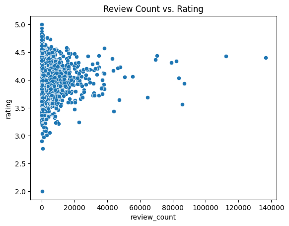

```python
_=sns.scatterplot(cleaned_goodreads.loc[:, ["rating", 'review_count']], x="review_count", y="rating")
# Title of the plot
plt.title('Review Count vs. Rating')
```

"There is no observable correlation between the number of reviews and ratings, as shown in the chart. The data suggests that the number of reviews does not have a linear effect on the ratings. Most books have fewer than 20,000 reviews, and their ratings tend to stay within the range of 3 to 5. Both books with low and high ratings generally have low review counts. We can see the books with low and high ratings are those with low reviews. The books that has a avergae rating close to the mean/median usually have higher reviews. Based on these observations linear regression is not the exact function to describe the data, so no Pearson (linear) correlation can be detected

## Exercise 7: Calculate the following descriptive statistics for the numerical features (e.g., number of reviews, average rating, etc.):

- Mean
- Median
- Standard Deviation
- Range
- Create a histogram or box plot for at least one of the numerical features, highlighting any skewness or outliers.

### Python Tools: Use pandas for data manipulation and matplotlib or seaborn for visualization.

```python
print("Mean rating:", cleaned_goodreads['rating'].mean())
print("Mean review count:", cleaned_goodreads['review_count'].mean())
print("Mean year:", cleaned_goodreads['year'].mean())
print("Mean rating count:", cleaned_goodreads['rating_count'].mean())
```

```
Mean rating: 4.041997330218589
Mean review count: 2374.3312197563823
Mean year: 1969.0850992824962
Mean rating count: 51183.89587852495
```

```python
print("Median rating:", cleaned_goodreads['rating'].median())
print("Median review count:", cleaned_goodreads['review_count'].median())
print("Median year:", cleaned_goodreads['year'].median())
print("Median rating count:", cleaned_goodreads['rating_count'].median())
```

```
Median rating: 4.05
Median review count: 936.0
Median year: 2002.0
Median rating count: 18072.0
```

```python
print("Standard deviation of rating:", cleaned_goodreads['rating'].std())
print("Standard deviation of review count:", cleaned_goodreads['review_count'].std())
print("Standard deviation of year:", cleaned_goodreads['year'].std())
print("Standard deviation of rating count:", cleaned_goodreads['rating_count'].std())
```

```
Standard deviation of rating: 0.2605090887217234
Standard deviation of review count: 5493.093328445107
Standard deviation of year: 185.38316893844993
Standard deviation of rating count: 137649.3356325423
```

```python
print("Range of rating:", cleaned_goodreads['rating'].max() - cleaned_goodreads['rating'].min())
print("Range of review count:", cleaned_goodreads['review_count'].max() - cleaned_goodreads['review_count'].min())
print("Range of year:", cleaned_goodreads['year'].max() - cleaned_goodreads['year'].min())
print("Range of rating count:", cleaned_goodreads['rating_count'].max() - cleaned_goodreads['rating_count'].min())
```

```
Range of rating: 3.0
Range of review count: 136455
Range of year: 3514
Range of rating count: 2958969
```

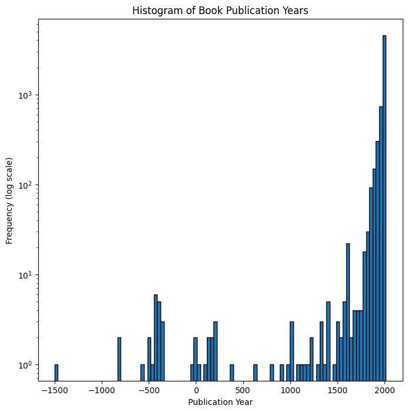

```python
# Created a histogram to show the distribution of book publication years
# Adjusted the y-axis to a logarithmic scale to better visualize smaller counts
# Used 100 bins for a detailed view of the data
# Set the figure size in inches
plt.figure(figsize=(8, 8))

# Create a histogram using matplotlib for 'year' column
plt.hist(cleaned_goodreads['year'], bins=100, edgecolor='black')

# Set the y-axis to a logarithmic scale to make graph more readable
plt.yscale('log')

# Add names axis and title
plt.xlabel('Publication Year')
plt.ylabel('Frequency (log scale)')
plt.title('Histogram of Book Publication Years')

# Show the plot
plt.show()
```

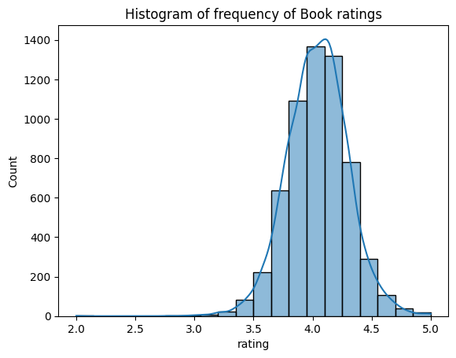

```python
#we chose to set the number of bins to 20 to create a more detailed histogram, as the majority of the data points are concentrated between 3 and 5.
#This bin size allows for better visualization of the distribution in this range, making the differences in frequencies clearer.
sns.histplot(cleaned_goodreads['rating'], bins=20, kde=True)

plt.title('Histogram of frequency of Book ratings')
```